# Python Quick Start Using Jupyter Notebooks

Dan Boschen & Josh Wilkins  
3/07/2018

```python
from matplotlib import pyplot as plt
%matplotlib inline
plt.rcParams['figure.figsize'] = (12.0, 9.0)
plt.rcParams['axes.facecolor'] = (1,1,1,0)
COLOR = 'gray'
plt.rcParams['text.color'] = COLOR
plt.rcParams['axes.labelcolor'] = COLOR
plt.rcParams['xtick.color'] = COLOR
plt.rcParams['ytick.color'] = COLOR
```

## Context

This is a “Quick Start” Guide and Lessons Learned for using Python through Anaconda and the Jupyter Notebook. Prior familiarity with Matlab is assumed so includes useful references for transitioning between Matlab and Python using Numpy.

[figure not shown]

## Useful References

1. [SciPy and NumPy](https://www.scipy.org/scipylib/faq.html) FAQ and quick primer
2. [Matplotlib pyplot](https://matplotlib.org/users/pyplot_tutorial.html) tutorial
3. [Markdown](https://github.com/adam-p/markdown-here/wiki/Markdown-Cheatsheet) cheatsheet
4. [Mathjax](http://jupyter-notebook.readthedocs.io/en/stable/examples/Notebook/Typesetting%20Equations.html) examples
5. [Pandas](https://pandas.pydata.org/pandas-docs/stable/10min.html) introduction
6. [Conda](https://conda.io/docs/user-guide/cheatsheet.html) cheat sheet
7. [Numpy](https://docs.scipy.org/doc/numpy-dev/user/numpy-for-matlab-users.html) for Matlab users
8. [Python](http://stsievert.com/blog/2015/09/01/matlab-to-python/) for Matlab users
9. [Python](https://learnpythonthehardway.org/book/) 2 book
10. [PEP8](https://www.python.org/dev/peps/pep-0008/) style guide
11. [Jupyter](https://www.dataquest.io/blog/jupyter-notebook-tips-tricks-shortcuts/) tips and tricks
12. [Jupyter](https://www.datacamp.com/community/tutorials/tutorial-jupyter-notebook) tutorial and history
13. [Magics](https://blog.dominodatalab.com/lesser-known-ways-of-using-notebooks/) introduction
14. [Loop Like A Native](https://nedbatchelder.com/text/iter.html), by Ned Batchelder

## Mentionable Tools

- **Ananconda**: Python distribution package tailored for data sciences. It includes thousands of popular data science packages, the Spyder IDE, Jupyter Notebook, and the conda pagkage and virtual environment manager for Windows, Linux and MacOS.
- **Conda**: Command line package and environment manager. (Anaconda Navigator is the GUI to Conda)
- **Cython**: C compiler for functions to make them faster
- **Matplotlib pyplot**: Plotting library that works like Matlab
- **NumPy**: Python extension module for efficient operation on arrays of data that allow python to serve as a high level language for manipulating numerical data similar to Matlab, providing vectorized operations.
- **Python 2.7 vs 3.3**: Differences are relatively minor but currently much more support in 2.7 in terms of documentation to help you along the way and 3rd party libraries.
- **Jupyter Notebook**: Combines computer code and rich text elements (paragraphs, equations, figures, links).
- **Markdown**: Lightweight markup language that is used in Jupyter Notebooks.
- **MathJax**: Markdown specific for writing mathematical formulas. The Markdown parser in Juypter Notebooks in MathJax aware.
- **Pandas**: Python package for data analysis for working with “relational” or “labeled” data in an easy and intuitive way (similar to spreadsheets).
- **pip**: Python package installer, similar to conda but with access to a larger package base. Conda has a new packaging format so conda and pip cannot be used interchangeably; conda cannot install a package in the pip format and vice versa. They can be used side by side but will not interoperate. Since the Anaconda environment is managed with conda, all updates to anaconda and installed libraries (from Anaconda) should be done using conda. Also search for packages on conda and install from there, and if not found try pip.
- **SciPy**: Scientific and numerical tools for Python supporting integration, ODE solvers, gradient optimization. Very fast, efficient and robust as mostly wrappers around existing open source C/Fortran scientific routines from http://www.netlib.org.
- **Spyder** IDE that comes with Anaconda

## Quick Start

Since many analyses can be done directly using Python within Jupyter Notebook, this quick start guide will focus on getting the user up and running with Juypyter Notebook first. A notable feature of the Jupyter Notebook is to document in rich text features along with making dynamic plots that can be changed on the fly as well as importing images and figures.

Future additions of this document can include using the Sypder IDE for code development. The Spyder IDE is more appropriate for extensive custom code (that can be developed and saved for import into future notebooks or other used in Python directly).

### Install Anaconda

Navigate [here](https://www.anaconda.com/download) and choose your platform with the latest install. Run the executable and follow the prompts to install.

### Enhancing the Jupyter Notebook with Plug-Ins

##### nbextensions:

Run the following commands from console to install:

```
pip install jupyter_contrib_nbextensions
jupyter contrib nbextension install --user
pip install jupyter_nbextensions_configurator
```

At this point you might have to restart Jupyter for it to take effect

After launching Jupyter, there should now be a NBExtensions tab.

By clicking on the Nbextesions tab from the main Jupyter navigator showing the directory file listing, the extensions can be selected. The following are ones I have been using:

- Equation Auto Numbering
- Hinterland
- Nbextensions dashboard tab
- Codefolding
- Cotrib_nbextensions_help_item
- Hide input all
- Nbextensions edit menu item
- Python Markdown
- Scratchpad
- Toggle all line numbers
- Jupyter-js-widgets/extension
- Skip-Traceback
- Split Cells Notebook
- Tree Filter
- Drag and Drop

## Example Markdown Block

### Subheading

#### Subheading

##### Subheading

Test in markdown area with **bold** and *italic* fonts

`#inline code'

```
# block code
x=5
y=2
print "The answer is " + str(x+y)
```

## Formulas using Mathjax

double $$ is centered:

$$x=5+\frac{4}{5}$$

single \$ is inline text: $\int 5x dx$

format for equation numbering:

\begin{equation} \sum_{x=5}^{12} 5x^2 \end{equation}

\begin{equation} \sum_{\hat{x}=5}^{12} 5\hat{x}^2 \end{equation}

Greek symbols: $\alpha \space \beta \space \gamma \space \Gamma \space \delta \space \Delta$

## Images and figures

Inserting images is done using HTML directly:

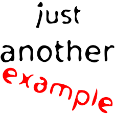

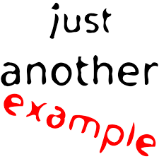

#### tables,

note that the colon placement sets the format :--- left justify ---: right justify :--: center

| Rev | Date | Author | Comments |
| --- | --- | --- | --- |
| 1 | 3/07/2018 | C. Daniel Boschen | Initial Draft |
| 2 | 3/09/2018 | C. Daniel Boschen | Additional notes from Josh |

## Common Notebook Configurations

```python
# common Notebook configurations
import numpy as np
import scipy
```

## Plotting and basic analysis example

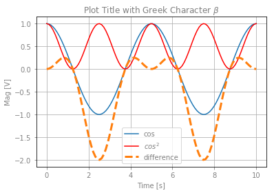

```python
# plotting and basic analysis example

x = np.linspace(0,10,100)
y = np.cos(2*np.pi*x/5)
y2 = y**2

plt.figure()

plt.plot(x,y, label='cos')                      # showing alternate label for legend
# note there is no "hold on/off" like in Matlab
plt.plot(x,y2, label = '$cos^2$', c='red')      # showing alternate line color
plt.plot(x, y-y2, label = 'difference', ls = '--', lw= 3)
plt.grid()
plt.legend()

plt.title(r'Plot Title with Greek Character $\beta$')
plt.xlabel('Time [s]')

# note the semi colon after the last command will supress output (from any cells in this block)
plt.ylabel('Mag [V]');
```

The following shows plotting with matplotlib with an object-oriented approach:

```
Text(0.5,1,u'FFT')
```

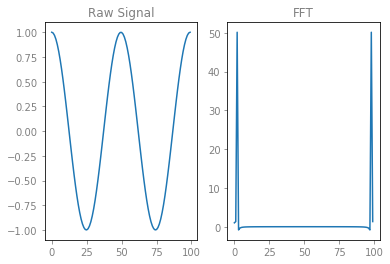

```python
fig, (ax1, ax2) = plt.subplots(1,2)
ax1.plot(y)
ax1.set_title('Raw Signal')
ax2.plot(np.real(np.fft.fft(y)))
ax2.set_title('FFT')
```

## Script, Function and Object Constructs

The following demonstrates function and ojbect constructs using a simple plotting task:

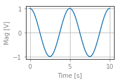

```python
# showing script, function and object constructs

# defining previous script as a function:

def plotMyWay(xData,yData,xTitle,yTitle):
    plt.figure(figsize=(3,2))
    plt.plot(xData,yData)
    plt.grid()
    plt.xlabel(xTitle)
    plt.ylabel(yTitle)
    plt.tight_layout()

# using the function
plotMyWay(x,y,'Time [s]', 'Mag [V]')
```

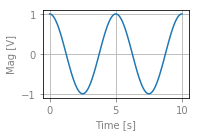

```python
# repeating above with an object construct

class myDataMyWay(object):
    def __init__(self, xData, yData):
        self.xData = xData
        self.yData = yData
    def plot(self, xTitle, yTitle):
        plt.figure(figsize=(3,2))
        plt.plot(self.xData,self.yData)
        plt.grid()
        plt.xlabel(xTitle)
        plt.ylabel(yTitle)
        plt.tight_layout()

# using class and method:
objExample = myDataMyWay(x,y)
objExample.plot('Time [s]', 'Mag [V]')
```

```python
#example function for use in notebook to print markdown from code block
def printmd(stringWithMarkdown):
    from IPython.display import Markdown, display
    display(Markdown(stringWithMarkdown))
```

## Making Markdown the Default Cell Block

Some steps to make markdown the default for new cell creation

- Run these 2 lines in python

```
From distutils.sysconfig import get_python_lib
print(get_python_lib()) + "\\notebook\\static\\notebook\\js"
```

- Go to the printed folder path
- Edit main.min.js
- Find these lines:

```
Notebook.options_default = {
   // can be any cell type, or the special values of
   // 'above', 'below', or 'selected' to get the value from another cell.
   default_cell_type: 'code',
   Header: true,
   Toolbar: true
};
```

- Change to default_cell_type: 'markdown',

## Magic Commands

Magic functions are predefined functions that are available in the notebook. Some of the more useful ones are detailed here.

Cell magics must appear first in the shell with no prior lines

To see all magic commands available in the given interpreter

```
%lsmagic
```

### HTML magic

Demonstrating html magic showing the entering of HTML command which will force all tables in document to be right justified

```python
%%html
<style>
table {float:right}
</style>
```

| Rev | Date | Author | Comments |
| --- | --- | --- | --- |
| 1 | 2/14/2018 | C. Daniel Boschen | Initial Draft |
| 2 | 2/14/2018 | C. Daniel Boschen | Added notes from Josh on making Markdown be the defualt |

### Profiling magic

Profiling is useful for optimizing code; scripts and functions can be timed to identify long running routines that could then by compiled to c with cython (compiling to c is why numpy and pandas are fast). Competing functions or approaches/algorithms can be assessed for efficiency.

```
%time function()    : will time a single run
%timeit function()  : will run a function multiple times
%prun function() : will run the function using the profiler showing time per operation
```

To compile long running functions to c:

If cython is not listed in the available cell magics above, install cython using conda install cython from the command prompt (best to use the Anaconda prompt for this):

```
conda install cython
```

```
%%cython
def newFunction(n)
    //function contents
```

```python
%time printmd('**Timing this statement!**')

printmd('**Timing a function once, compary numpy and scipy fft **')
from scipy.fftpack import fft
%time fft(np.random.rand(5000000))
%time np.fft.fft(np.random.rand(5000000))


printmd('**Repeat with timing with multiple runs**')
%timeit fft(np.random.rand(5000000))
%timeit np.fft.fft(np.random.rand(5000000))
```

**Timing this statement!**

```
Wall time: 5 ms
```

**Timing a function once, compary numpy and scipy fft**

```
Wall time: 330 ms
Wall time: 416 ms
```

**Repeat with timing with multiple runs**

```
10 loops, best of 3: 161 ms per loop
1 loop, best of 3: 249 ms per loop
```

## Windows Extension

Adding a windows extension to your machine to launch jupyter from Windows Explorer

[figure not shown]

You might find it in program files  
Edit the jupyter.txt file in this directory and replace every instance of my path with your path  
Save the changes, change txt suffix to reg and then double click the reg file to add the extension to your machine  
To use, go to the directory you want to open up jupyter notebook and right click, then select the “Open Jupyter Notebook Here”

## Notebook Styling with CSS

The notebook can be styled using css. Press F12 for html class names and tags for css handles. As an example, I've changed the background color of the input cells

```python
from IPython.core.display import HTML

def css_styling():
    styles = open("./custom.css", "r").read()
    return HTML(styles)
css_styling()
```